# Brain Extraction/Segmentation

## Overall Pipeline

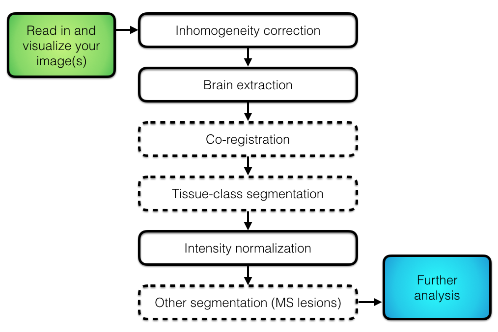

## Brain Extraction 3 Different Attempts

In this tutorial we will discuss performing brain segmentation using:

- the brain extraction tool (BET) (Smith 2002) in `FSL` (Jenkinson et al. 2012)
  - without bias correction (method 1) and with (method 2)
- a multi-atlas approach, called “multi-atlas label fusion” with the `malf` command (method 3).
- (extra slides) a robust version using a wrapper function in `extrantsr`, `fslbet_robust`

## MS Lesion T1

Let’s reset and read in the T1 image from a MS lesion data set:

```r
library(neurobase)
t1_fname = "training01_01_t1.nii.gz"
t1 = neurobase::readnii(t1_fname)
rt1 = robust_window(t1, probs = c(0, 0.975));
red0.5 = scales::alpha("red", 0.5) # for plotting later
```

## T1-weighted T1 Image

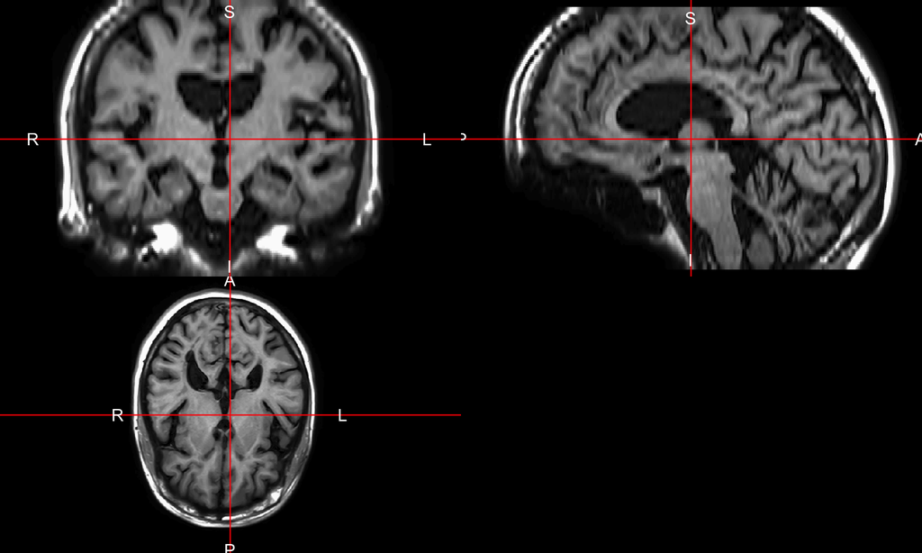

```r
ortho2(rt1)
```

## Attempt 1: Brain Extraction of T1 image using BET

Here we will use FSL’s Brain Extraction Tool (BET) to extract the brain tissue from the rest of the image (general overview):

- 2nd and 98th percentiles are calculated. (98th - 2nd) * 10% + 2nd percentile used to threshold out background
- From non-thresholded voxels - calculate center of gravity (COG)
- Calculate radius of brain and median intensity of all points within “spherical brain” (used in last step)
- Perform region growing and iterating to get brain surface
- Smooth surface
- Use median intensity to shrink surface to the “real” surface

## Attempt 1: Brain Extraction of T1 image using BET

`fslr` - wraps FSL commands to use in R - registration, image manipulation

`fslr::fslbet` - takes in a filename/nifti and calls FSL `bet` function - additional options can be passed to FSL command in using `opts`

```r
library(fslr)
ss = fslbet(infile = t1_fname)
```

## FSL BET Results - Missing Brain Tissues (Posterior)

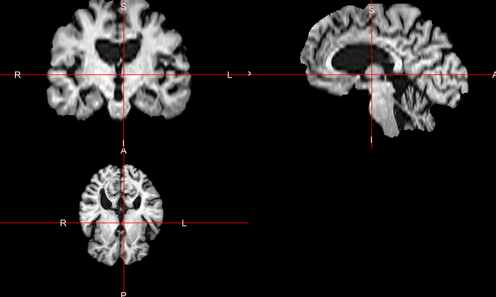

```r
ortho2(robust_window(ss))
```

## FSL BET Results not Satisfactory

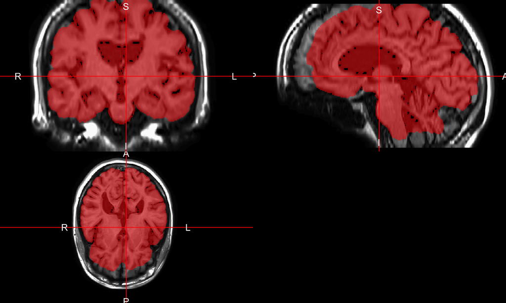

```r
ortho2(rt1, ss > 0, col.y = red0.5)
```

## Attempt 2: Bias Correct before BET (recommended)

Before doing skull-stripping/brain extraction, we would do bias correction:

```r
library(extrantsr)
bc_img = bias_correct(file = t1, correction = "N4")
```

```r
bc_bet = fslbet(bc_img); ortho2(bc_img, bc_bet > 0, col.y = red0.5)
```

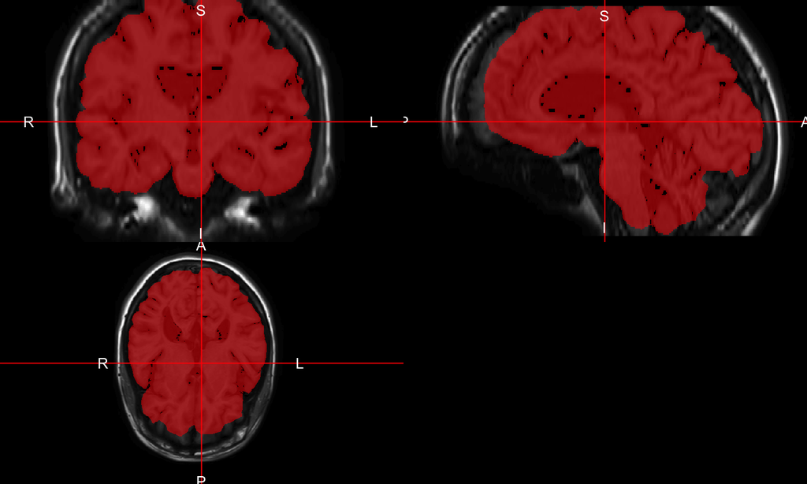

## MALF for Skull Stripping

Figure from Multi-Atlas Skull Stripping method paper (Doshi et al. 2013):

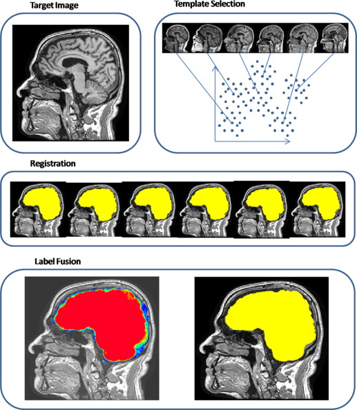

- Register templates to an image using the T1 for that subject
- Apply transformation to the label/mask
- Average each voxel over all templates
  - there are “smarter” (e.g. weighted) ways

## MALF - use `extrantsr::malf`

- Function requires arguments: `template.images` (T1-weighted images in this case) and `template.structs` (labels/structures/masks, brain masks here)
- We will use the `extrantsr::malf` function
  - Performs non-linear registration using Symmetric Normalization (`SyN`) (Avants et al. 2008), a form of diffeomorphic registration:
  - combines the template structures

```r
library(malf.templates) # load the data package
library(extrantsr)
timgs = mass_images(n_templates = 5) # let's register 5 templates
ss = extrantsr::malf(
  infile = bc_img,
  template.images = timgs$images,
  template.structs = timgs$masks,
  keep_images = FALSE # don't keep the registered images
)
mask = ss > 0
```

## MALF performs well

```r
mask = readnii("training01_01_t1_mask.nii.gz") # already computed
```

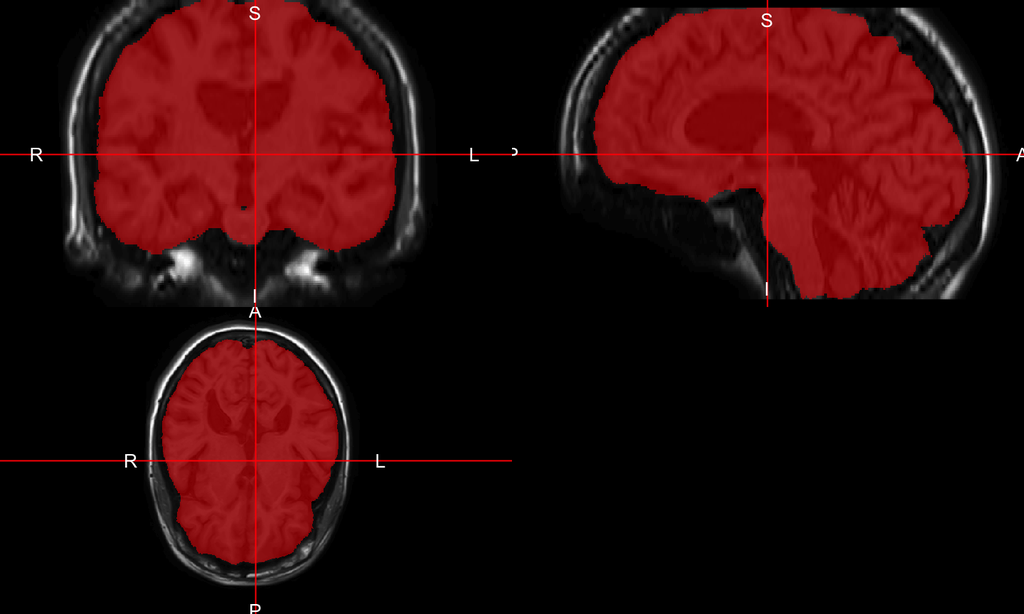

```r
ortho2(bc_img, mask, col.y = red0.5)
```

## Conclusions from the MS data

- FSL BET can perform brain extraction (additional ex shows when it works)
  - It did not work sufficiently here
  - There are options you can change for performance
- Bias-correction before brain extraction is a good idea
  - Especially if the method depends on intensities
  - Didn’t change the results here
- MALF/MASS is a good option, but needs templates and is computationally expensive
  - weighted templates or local weighting is done in other software (not discussed)

## Website

http://johnmuschelli.com/imaging_in_r

## Extra Slides are showing additional BET options

## Additional Example

FSL BET did not work in the previous data set. It works in many cases, though. We will look at a subject from the kirby21 dataset (Landman et al. 2011).

```r
library(kirby21.t1)
t1_fname = get_t1_filenames()[1]
t1 = readnii(t1_fname)
```

## T1 image has the neck!

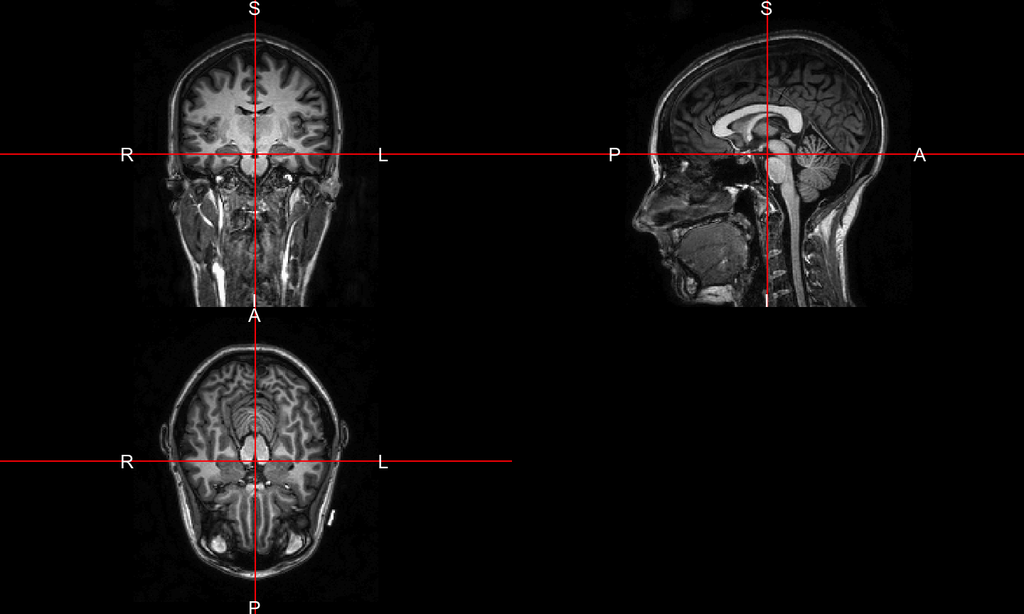

```r
ortho2(robust_window(t1))
```

## Neck messes up BET

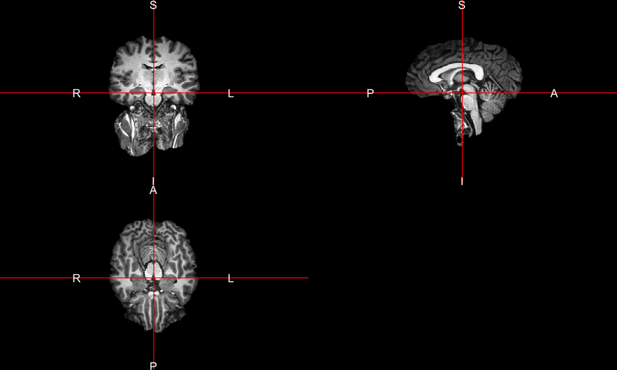

```r
ss = fslbet(infile = t1_fname); ortho2(robust_window(ss))
```

## Recommend to Bias Correct first: not fixed

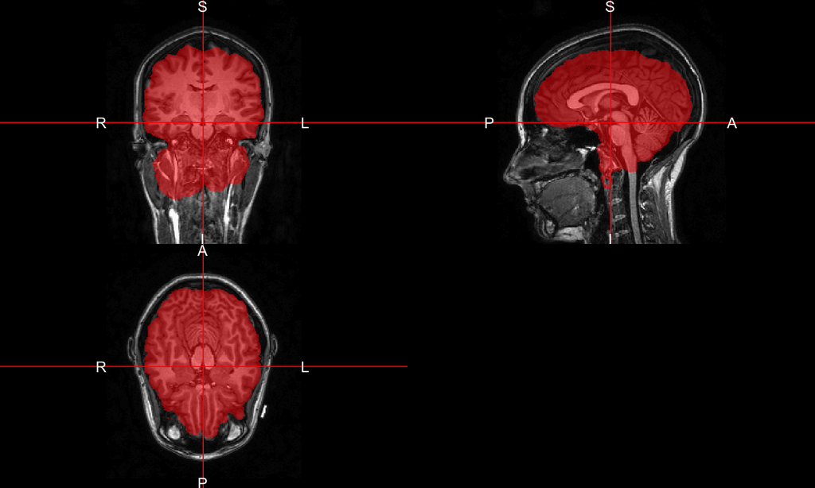

```r
bc_img = bias_correct(t1, correction = "N4");
bc_bet = fslbet(bc_img)
ortho2(robust_window(t1), bc_bet > 0, col.y = red0.5)
```

## BET with neck removal

We use the modification of BET in `extrantsr`, which is called through `fslbet_robust`. `fslbet_robust`:

- bias correct image
- remove neck (`double_remove_neck` performs 2 registration steps, more robust than one (which is the default).)
- run BET
- estimate center of gravity (COG)
- run BET again with new COG

## `fslbet_robust` syntax

```r
ss = extrantsr::fslbet_robust(
  t1,
  remover = "double_remove_neck",
  correct = TRUE,
  correction = "N4",
  recog = TRUE)
```

## BET with neck removal - works well!

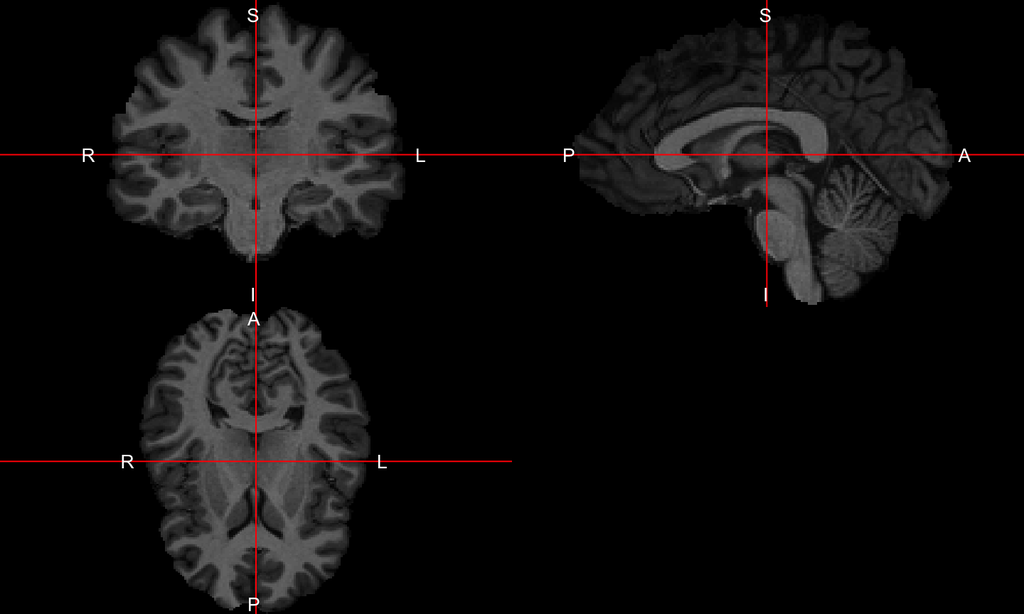

```r
ortho2(ss)
```

## Conclusions

- Brain extraction allows you to analyze the brain only
  - Important for tissue segmentation/registration
- BET may work (look at your data!)
  - Should bias correct first
  - May need to remove neck
  - High values may affect results - may need to remove/Winsorize them

## Website

http://johnmuschelli.com/imaging_in_r

## References

Avants, B. B., C. L. Epstein, M. Grossman, and J. C. Gee. 2008. “Symmetric Diffeomorphic Image Registration with Cross-Correlation: Evaluating Automated Labeling of Elderly and Neurodegenerative Brain.” *Medical Image Analysis*, Special issue on the third international workshop on biomedical image registration - WBIR 2006, 12 (1):26–41. https://doi.org/10.1016/j.media.2007.06.004.

Doshi, Jimit, Guray Erus, Yangming Ou, Bilwaj Gaonkar, and Christos Davatzikos. 2013. “Multi-Atlas Skull-Stripping.” *Academic Radiology* 20 (12). Elsevier:1566–76.

Jenkinson, Mark, Christian F. Beckmann, Timothy E. J. Behrens, Mark W. Woolrich, and Stephen M. Smith. 2012. “FSL.” *NeuroImage* 62 (2):782–90. https://doi.org/10.1016/j.neuroimage.2011.09.015.

Landman, Bennett A, Alan J Huang, Aliya Gifford, Deepti S Vikram, Issel Anne L Lim, Jonathan AD Farrell, John A Bogovic, et al. 2011. “Multi-Parametric Neuroimaging Reproducibility: A 3-T Resource Study.” *Neuroimage* 54 (4). Elsevier:2854–66. https://www.nitrc.org/projects/multimodal/.

Smith, Stephen M. 2002. “Fast Robust Automated Brain Extraction.” *Human Brain Mapping* 17 (3):143–55. https://doi.org/10.1002/hbm.10062.